# ETC5512: Solutions for Tutorial 7

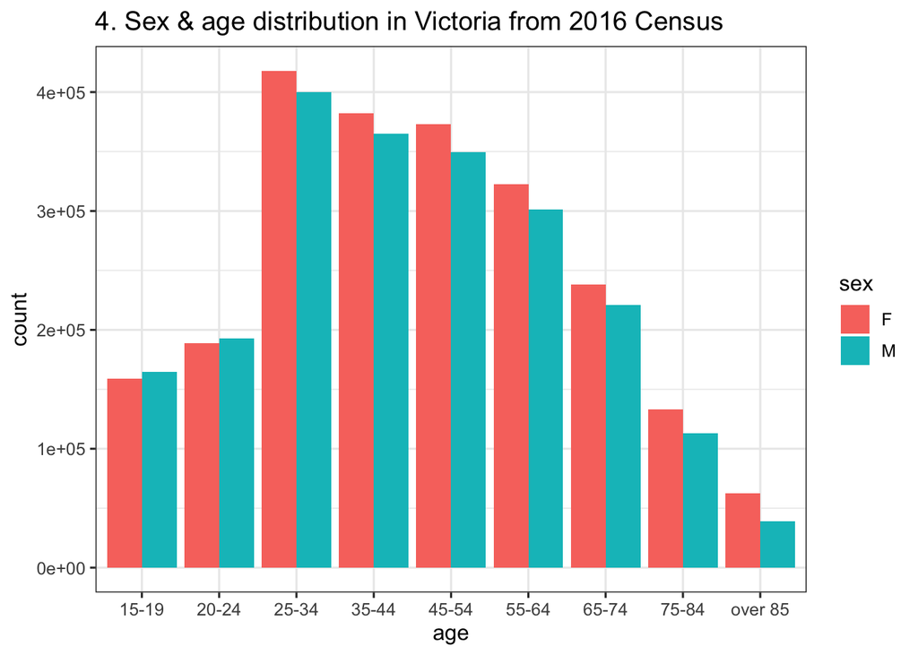

```r
STE_G17tidy2 %>%
   group_by(sex, age) %>%
   summarise(count = sum(count)) %>%
   ggplot() +
      geom_col(aes(x = age, y = count, fill = sex), position = "dodge") +
      ggtitle("4. Sex & age distribution in Victoria from 2016 Census") +
      theme_bw(base_size = 12)
```

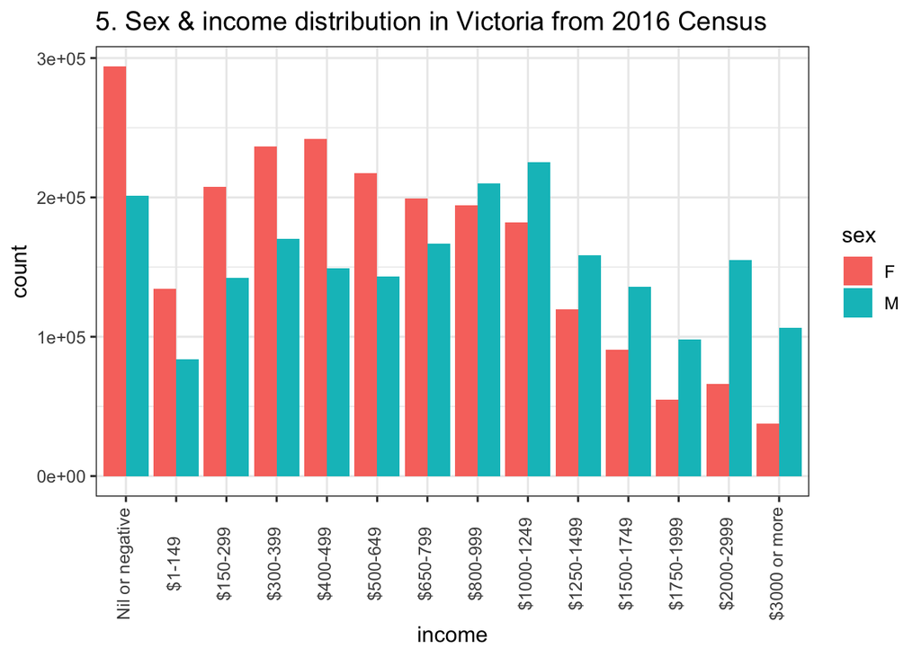

```r
STE_G17tidy2 %>%
   group_by(sex, income) %>%
   summarise(count = sum(count)) %>%
   ggplot() +
      geom_col(aes(x = income, y = count, fill = sex), position = "dodge") +
      ggtitle("5. Sex & income distribution in Victoria from 2016 Census") +
      theme_bw(base_size = 12) +
      theme(axis.text.x = element_text(angle = 90, vjust = 0.3))
```

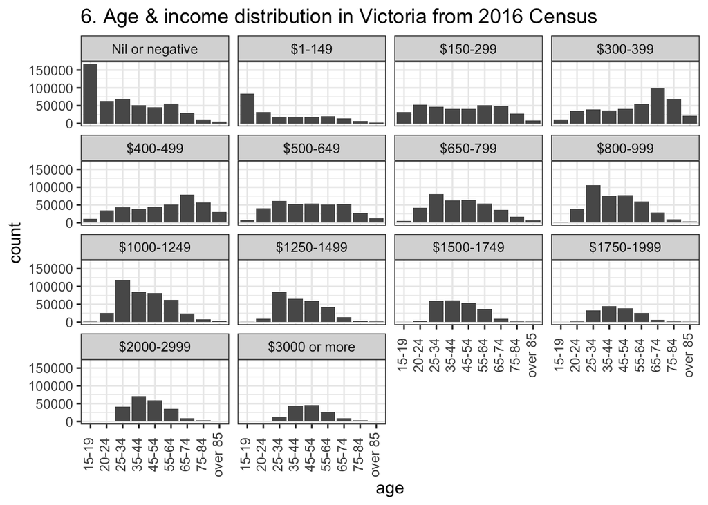

```r
STE_G17tidy2 %>%
   group_by(age, income) %>%
   summarise(count = sum(count)) %>%
   ggplot() +
      geom_col(aes(x = age, y = count), position = "dodge") +
      facet_wrap(~income) +
      ggtitle("6. Age & income distribution in Victoria from 2016 Census") +
      theme_bw(base_size = 12) +
      theme(axis.text.x = element_text(angle = 90, vjust = 0.3))
```

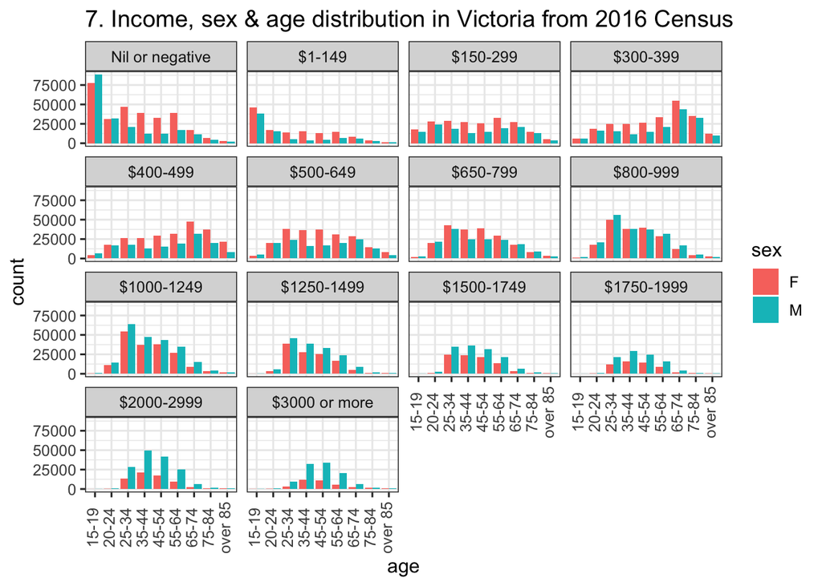

```r
STE_G17tidy2 %>%
   ggplot(aes(x = age, y = count, fill = sex)) +
      geom_col(position = "dodge") +
   facet_wrap(~income) +
   theme_bw(base_size = 12) +
   theme(axis.text.x = element_text(angle = 90, vjust = 0.3)) +
   ggtitle("7. Income, sex & age distribution in Victoria from 2016 Census")
```

## 💃 Exercise 7C

We will use the STE data to extract the relevant statistics.

```r
n_women_15_54 <- STE_G17tidy %>%
   filter(age_min >=15 & age_max <= 54 & sex == "F") %>%
   pull(count) %>%
   sum()

n_vic <- 5926624 # This number needs to be extracted from https://quickstats.censusdata.abs.gov.au/census_services/getproduct/census/2016/quickstat/2?opendocument

n_people_25_34_earn_1750_or_more <-  STE_G17tidy %>%
   filter(age_min >=25 & age_max <= 34 & sex == "P" & income_min >= 1750) %>%
   pull(count) %>%
   sum()

n_man_25_44 <-  STE_G17tidy %>%
   filter(age_min >=25 & age_max <= 44 & sex == "M") %>%
   pull(count) %>%
   sum()

n_man_25_44_earn_1500_or_less <-  STE_G17tidy %>%
   filter(age_min >=25 & age_max <= 44 & sex == "M" & income_max <= 1500) %>%
   pull(count) %>%
   sum()
```

According to the 2016 Census data:

- There are 1,520,073 women in Victoria are aged between 15-54 years old.
- The proportion of people in Victoria that are 25-34 years old (inclusive) and earn $1750 or more per week is 0.0149355.
- If I randomly select a man from all the man aged 25-44 years old in Victoria, the probability that the man I selected earns less than $1500 per week is 0.684063.